# Power analysis

PSA 008

R&R v. 5

# README

Here, we take the `.csv` output of the power simulations (`power-simulations.R`) and generate the plots used to determine the sample size. The plots are included in the supplementary information. For each research question, the sample size corresponds to the appropriate number of both countries (K = 30, 40, 50) and participants per country (N = 100, 150, 200, 250).

```r
## packages
library(tidyverse)
library(simr)
library(lmerTest)
library(sjPlot)
library(patchwork)

## read csv files and save to object
for(rq in c("rq1", "rq2", "rq3")) {
    assign(paste("pwr_", rq, sep = ""),
           read_csv(paste("./pwr-", rq, ".csv", sep = "")))
}
```

# 1 Research Question 1

For RQ1, we considered the effect of minimal group (in-group vs out-group) on one of the three outcomes. We used a conservative minimal group effect size of $d$ = 0.19, implying a beta for minimal group = 0.1. The effect size was based on that reported for experiments lacking mutual independence in Balliet, Wu, and De Dreu (2014) ($d$ = 0.19), which is about half the effect size of bias in allocation tasks for artificial groups reported in Lane (2016) ($d$ = 0.37). We also tested smaller (beta = 0.05) and larger (beta = 0.15) values. As the minimal group effect was assumed to vary across countries, we allowed random slopes for the minimal group effect to vary within country (slope variance = 0.01, 0.02, 0.03).

Assuming beta = 0.1, the slope variances change the distribution of expected effects across countries as follows (Figure 1.1). For slope variance = 0.01, we expect around 68% of the countries to have an effect between 0 and 0.20, with the remainder having more extreme effects. For slope variance = 0.02, we expect around 68% of the countries to have an effect between -0.05 and 0.25. For variance = 0.03, we expect around 68% of the countries to have an effect between -0.10 and 0.30. Thanks to Reviewer 3 for 1.1.

Figure 1.1: Expected effects across countries for RQ1

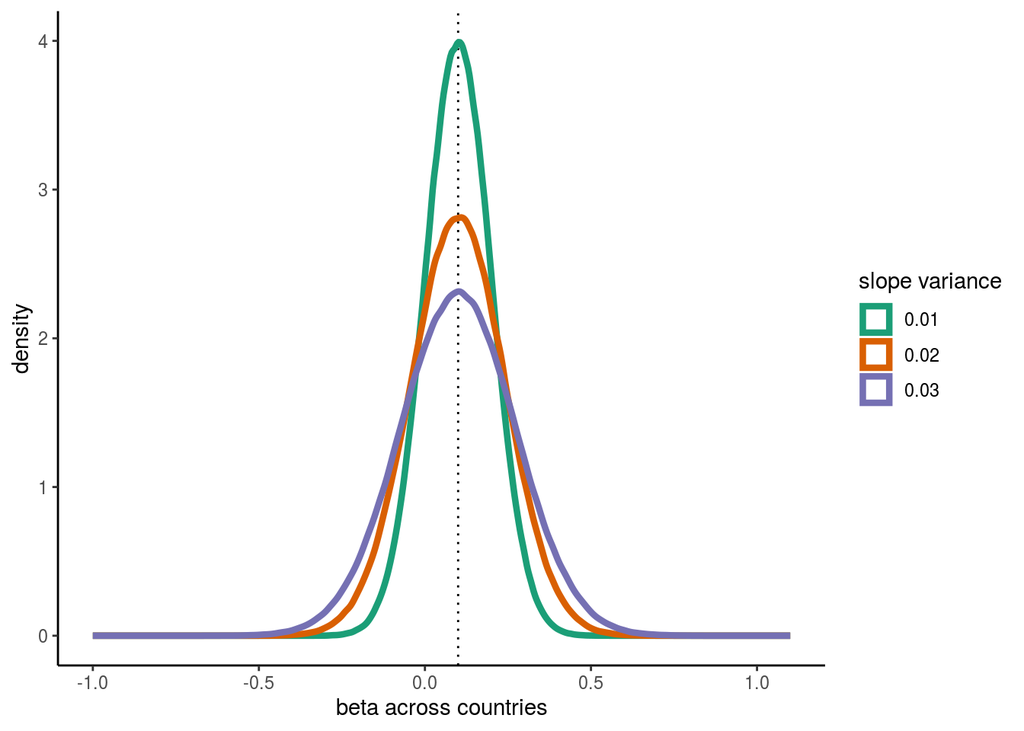

```r
## number of repeats for distribution
n_times <- 1000000

## dataframe of expected effects
df_slopes <-

  bind_rows(
  tibble(
    slope = rep("0.01", times = n_times),
    values = rnorm(n_times, 0.1, sqrt(0.01))),
  tibble(
    slope = rep("0.02", times = n_times),
    values = rnorm(n_times, 0.1, sqrt(0.02))),
  tibble(
    slope = rep("0.03", times = n_times),
    values = rnorm(n_times, 0.1, sqrt(0.03)))
  )

## plot expected effects
ggplot(data.frame(x = c(-1.0, 1.0)), aes(x = x)) +
  geom_vline(xintercept = 0.1, linetype = 3) +
  geom_density(data = df_slopes,
               aes(x = values, colour = slope),
               linewidth = 1.5) +
  scale_x_continuous(limits = c(-1, 1.1)) +
  scale_y_continuous(limits = c(0, 4)) +
  scale_colour_brewer(palette = "Dark2",
                        name = "slope variance",
                        na.translate = FALSE) +
    labs(x = "beta across countries",
         y = "density") +
   theme_classic()
```

Figure 1.2 shows the power obtained for RQ1. We achieve power >90% for all combinations of effect size and slope variance when K ≥ 50 and beta ≥ 0.1. At N = 200, we achieve power >95% for beta = 0.1 when the slope variance is ≤ 0.02 and K ≥ 40.

Figure 1.2: RQ1 power analysis

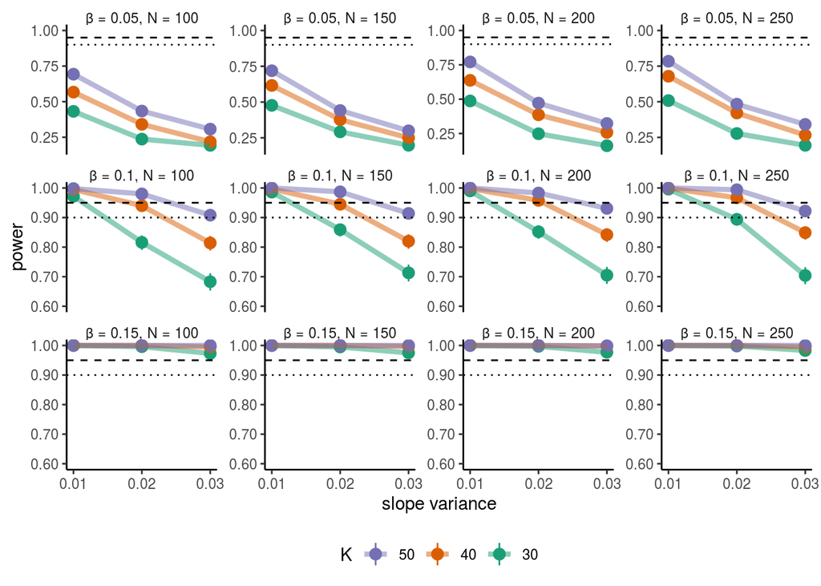

```r
## add X = to facet label and consistent y axis
subjects_labeller <- function(x) paste0("N = ", x)
beta_labeller <- function(x) paste0("\u03B2 = ", x)
formatter <- function(...){function(x) format(round(x, 2), ...)}

## plot
plot <- pwr_rq1 %>%
    mutate(countries = as.factor(countries)) %>%
    ggplot() +
    aes(x = beta_variance, y = mean, group = countries, colour = countries) +
    geom_linerange(aes(ymin = lower, ymax = upper)) +
    geom_point(size = 3) +
    geom_line(alpha = 0.5, linewidth = 1.5) +
    geom_hline(yintercept = 0.95, linetype = 2) +
    geom_hline(yintercept = 0.90, linetype = 3) +
    geom_hline(yintercept = 1.00, alpha = 0) +
    geom_hline(yintercept = 0.60, alpha = 0) +
    scale_x_continuous(breaks = c(0.01, 0.02, 0.03)) +
     scale_y_continuous(labels = formatter(nsmall = 2)) +
#ylim(0.5, 1.00) +
       facet_wrap(beta ~ subjects,
               ncol = 4,
               scales = "free_y",
               labeller = labeller(subjects = as_labeller(subjects_labeller), beta = as_labeller(beta_labeller), .multi_line = FALSE)) +
    scale_colour_brewer(palette = "Dark2",
                        name = "K",
                        na.translate = FALSE) +
    labs(x = "slope variance",
         y = "power") +
    guides(colour = guide_legend(reverse = TRUE)) +
    theme_classic() +
    theme(legend.position="bottom",
           panel.spacing = unit(0.5, "lines"),
          strip.text.x = element_text(margin = margin(unit(1, "lines"))),
          strip.background = element_blank(),
          strip.placement = "outside")
plot
```

```r
plot_save <- plot +
  labs(title = "RQ1 power analysis") +
  ## for legibility of printed plot, comment out size
  theme_classic(base_size = 15) +
      theme(legend.position="bottom",
           panel.spacing = unit(0.5, "lines"),
          strip.text.x = element_text(margin = margin(unit(1, "lines"))),
          strip.background = element_blank(),
          strip.placement = "outside")

plot_save %>%
  ggsave(filename = paste(Sys.Date(), "power-rq1.png", sep = "_"),
         bg = "transparent")
```